# multitask_s1_paramsBehav

K. Garner

28 August 2018

### Summary

Having identified the candidate network underpinning modulations in connectivity due to multitasking demands, we sought to identify whether parameter estimates for each subject correlate with the observed behaviour. We would expect the parameter estimates to correspond to multitasking costs in behaviour, rather than to observations of response time under single-task conditions (i.e. when there is no multitasking).

First I present the correlations between parameter estimates and single-task response times (separately for the visual-manual [VM] and auditory-manual [AM] tasks), then I present the correlations between parameter estimates and multi-task response times (seperately for VM and AM). Then I show the correlations between parameter estimates and the multitask cost estimated for each task separately (i.e. VM mixed - VM single | AM mixed - AM single). Lastly I show correlations between parameter estimates and the mean multitasking cost [mean(VM mixed - VM single, AM mixed - AM single)], and the summed multitasking cost [sum(VM mixed - VM single, AM mixed - AM single)]

## Q. Do b parameters correlate with single-task RTs or with multitasking cost? (no)

### VM single-task

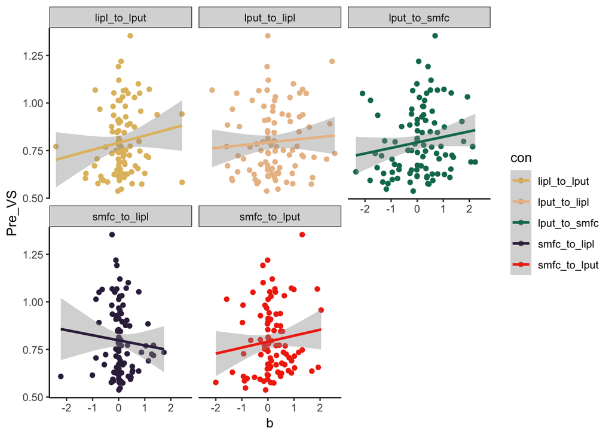

```r
draw.scatters(data, "Pre_VS")
```

```r
lapply(unique(data$con), get.cors, data = data, dv = "Pre_VS", method="spearman")
```

```
## [[1]]
##
##  Spearman's rank correlation rho
##
## data:  x and y
## S = 124450, p-value = 0.1293
## alternative hypothesis: true rho is not equal to 0
## sample estimates:
##       rho
## 0.1559216
##
##
## [[2]]
##
##  Spearman's rank correlation rho
##
## data:  x and y
## S = 138510, p-value = 0.557
## alternative hypothesis: true rho is not equal to 0
## sample estimates:
##        rho
## 0.06058058
##
##
## [[3]]
##
##  Spearman's rank correlation rho
##
## data:  x and y
## S = 119060, p-value = 0.06035
## alternative hypothesis: true rho is not equal to 0
## sample estimates:
##       rho
## 0.1924986
##
##
## [[4]]
##
##  Spearman's rank correlation rho
##
## data:  x and y
## S = 161550, p-value = 0.3538
## alternative hypothesis: true rho is not equal to 0
## sample estimates:
##         rho
## -0.09566636
##
##
## [[5]]
##
##  Spearman's rank correlation rho
##
## data:  x and y
## S = 132660, p-value = 0.3306
## alternative hypothesis: true rho is not equal to 0
## sample estimates:
##       rho
## 0.1002306
```

```r
#Pre_VS_ps = c(0.3129, 0.02082, 0.2273, 0.8235, 0.4002)
#p.adjust(Pre_VS_ps, method="fdr")
```

### AM single-task

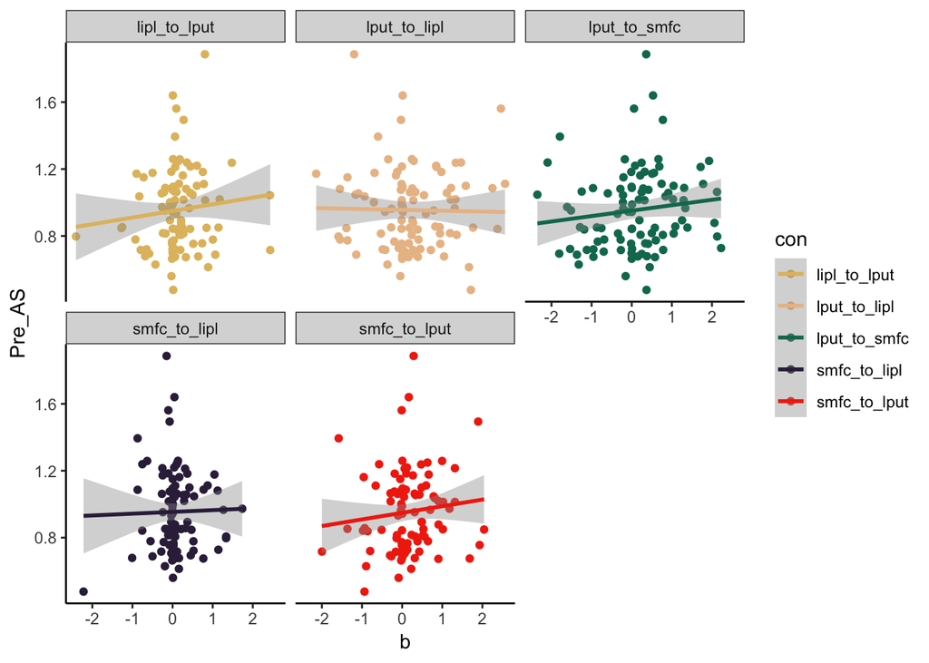

```r
draw.scatters(data, "Pre_AS")
```

```r
lapply(unique(data$con), get.cors, data = data, dv = "Pre_AS", method="spearman")
```

```
## [[1]]
##
##  Spearman's rank correlation rho
##
## data:  x and y
## S = 128090, p-value = 0.2024
## alternative hypothesis: true rho is not equal to 0
## sample estimates:
##       rho
## 0.1312538
##
##
## [[2]]
##
##  Spearman's rank correlation rho
##
## data:  x and y
## S = 147910, p-value = 0.9755
## alternative hypothesis: true rho is not equal to 0
## sample estimates:
##          rho
## -0.003174173
##
##
## [[3]]
##
##  Spearman's rank correlation rho
##
## data:  x and y
## S = 119460, p-value = 0.06416
## alternative hypothesis: true rho is not equal to 0
## sample estimates:
##       rho
## 0.1897585
##
##
## [[4]]
##
##  Spearman's rank correlation rho
##
## data:  x and y
## S = 146870, p-value = 0.9701
## alternative hypothesis: true rho is not equal to 0
## sample estimates:
##         rho
## 0.003879557
##
##
## [[5]]
##
##  Spearman's rank correlation rho
##
## data:  x and y
## S = 128760, p-value = 0.2182
## alternative hypothesis: true rho is not equal to 0
## sample estimates:
##       rho
## 0.1267227
```

### VM mixed

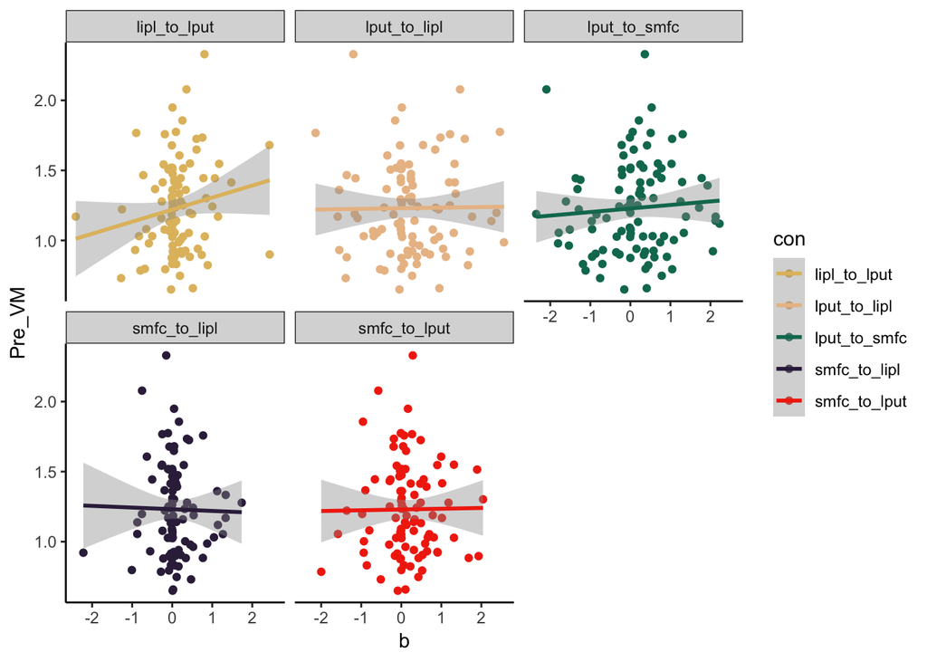

```r
draw.scatters(data, "Pre_VM")
```

```r
lapply(unique(data$con), get.cors, data = data, dv = "Pre_VM", method="spearman")
```

```
## [[1]]
##
##  Spearman's rank correlation rho
##
## data:  x and y
## S = 127060, p-value = 0.1793
## alternative hypothesis: true rho is not equal to 0
## sample estimates:
##       rho
## 0.1382262
##
##
## [[2]]
##
##  Spearman's rank correlation rho
##
## data:  x and y
## S = 147610, p-value = 0.9912
## alternative hypothesis: true rho is not equal to 0
## sample estimates:
##          rho
## -0.001139447
##
##
## [[3]]
##
##  Spearman's rank correlation rho
##
## data:  x and y
## S = 131110, p-value = 0.2822
## alternative hypothesis: true rho is not equal to 0
## sample estimates:
##       rho
## 0.1107434
##
##
## [[4]]
##
##  Spearman's rank correlation rho
##
## data:  x and y
## S = 156320, p-value = 0.56
## alternative hypothesis: true rho is not equal to 0
## sample estimates:
##         rho
## -0.06022809
##
##
## [[5]]
##
##  Spearman's rank correlation rho
##
## data:  x and y
## S = 148050, p-value = 0.9682
## alternative hypothesis: true rho is not equal to 0
## sample estimates:
##          rho
## -0.004123711
```

- no correlations achieve statistical significance

### AM mixed

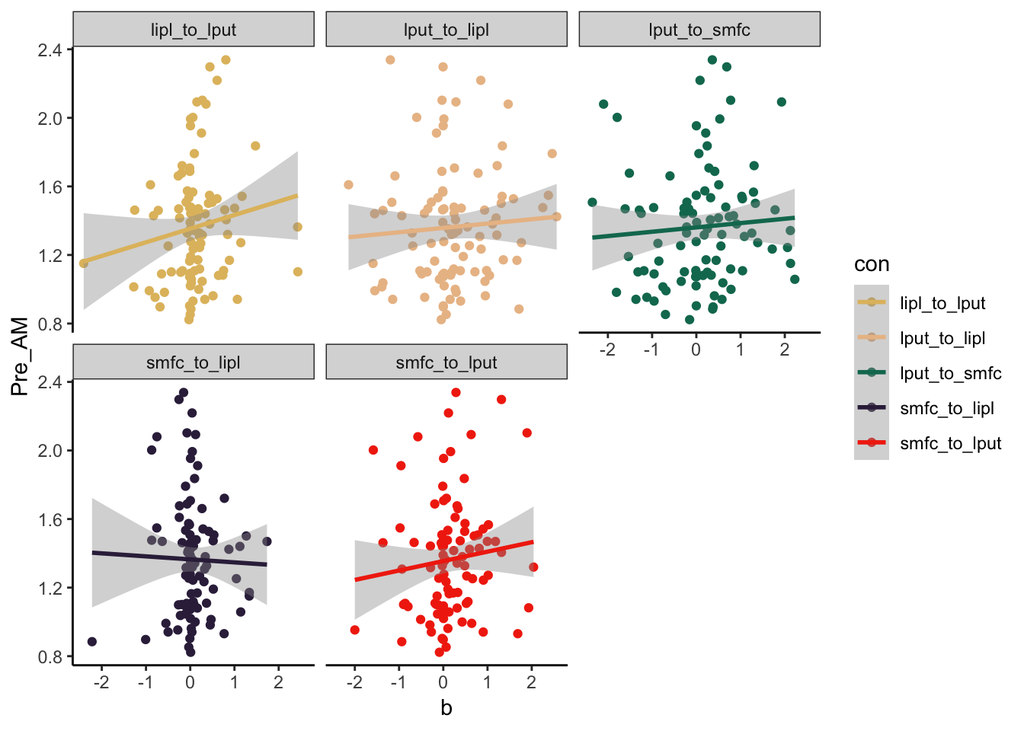

```r
draw.scatters(data, "Pre_AM")
```

```r
lapply(unique(data$con), get.cors, data = data, dv = "Pre_AM", method="spearman")
```

```
## [[1]]
##
##  Spearman's rank correlation rho
##
## data:  x and y
## S = 124080, p-value = 0.1231
## alternative hypothesis: true rho is not equal to 0
## sample estimates:
##       rho
## 0.1584582
##
##
## [[2]]
##
##  Spearman's rank correlation rho
##
## data:  x and y
## S = 137550, p-value = 0.5154
## alternative hypothesis: true rho is not equal to 0
## sample estimates:
##       rho
## 0.0670917
##
##
## [[3]]
##
##  Spearman's rank correlation rho
##
## data:  x and y
## S = 128190, p-value = 0.2045
## alternative hypothesis: true rho is not equal to 0
## sample estimates:
##       rho
## 0.1305616
##
##
## [[4]]
##
##  Spearman's rank correlation rho
##
## data:  x and y
## S = 149890, p-value = 0.8725
## alternative hypothesis: true rho is not equal to 0
## sample estimates:
##         rho
## -0.01658986
##
##
## [[5]]
##
##  Spearman's rank correlation rho
##
## data:  x and y
## S = 120490, p-value = 0.0747
## alternative hypothesis: true rho is not equal to 0
## sample estimates:
##       rho
## 0.1827998
```

### VM multitasking cost (VM mixed - VM single)

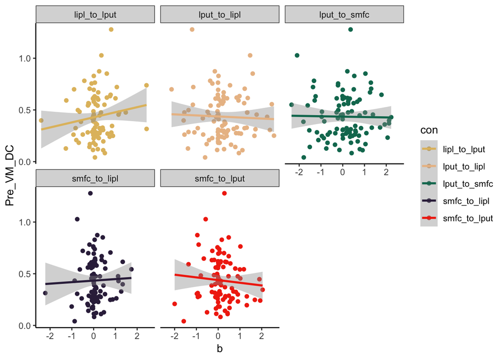

```r
draw.scatters(data, "Pre_VM_DC")
```

```r
lapply(unique(data$con), get.cors, data = data, dv = "Pre_VM_DC", method="spearman")
```

```
## [[1]]
##
##  Spearman's rank correlation rho
##
## data:  x and y
## S = 134720, p-value = 0.4032
## alternative hypothesis: true rho is not equal to 0
## sample estimates:
##        rho
## 0.08628624
##
##
## [[2]]
##
##  Spearman's rank correlation rho
##
## data:  x and y
## S = 151220, p-value = 0.8041
## alternative hypothesis: true rho is not equal to 0
## sample estimates:
##         rho
## -0.02561042
##
##
## [[3]]
##
##  Spearman's rank correlation rho
##
## data:  x and y
## S = 145300, p-value = 0.888
## alternative hypothesis: true rho is not equal to 0
## sample estimates:
##        rho
## 0.01454151
##
##
## [[4]]
##
##  Spearman's rank correlation rho
##
## data:  x and y
## S = 140940, p-value = 0.6696
## alternative hypothesis: true rho is not equal to 0
## sample estimates:
##        rho
## 0.04410623
##
##
## [[5]]
##
##  Spearman's rank correlation rho
##
## data:  x and y
## S = 164220, p-value = 0.2692
## alternative hypothesis: true rho is not equal to 0
## sample estimates:
##        rho
## -0.1137819
```

```r
#Pre_VS_ps = c(0.0909, 0.1628, 0.6785, 0.8459, 0.0164)
#p.adjust(Pre_VS_ps, method="fdr")
```

### AM multitasking cost (AM mixed - AM single)

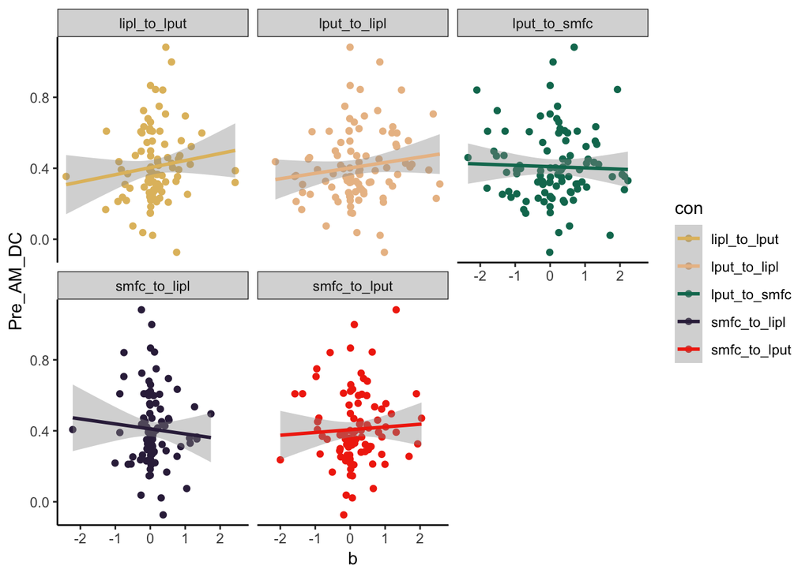

```r
draw.scatters(data, "Pre_AM_DC")
```

```r
lapply(unique(data$con), get.cors, data = data, dv = "Pre_AM_DC", method="spearman")
```

```
## [[1]]
##
##  Spearman's rank correlation rho
##
## data:  x and y
## S = 125920, p-value = 0.1559
## alternative hypothesis: true rho is not equal to 0
## sample estimates:
##       rho
## 0.1459446
##
##
## [[2]]
##
##  Spearman's rank correlation rho
##
## data:  x and y
## S = 129110, p-value = 0.227
## alternative hypothesis: true rho is not equal to 0
## sample estimates:
##       rho
## 0.1243353
##
##
## [[3]]
##
##  Spearman's rank correlation rho
##
## data:  x and y
## S = 142200, p-value = 0.7304
## alternative hypothesis: true rho is not equal to 0
## sample estimates:
##        rho
## 0.03556701
##
##
## [[4]]
##
##  Spearman's rank correlation rho
##
## data:  x and y
## S = 146300, p-value = 0.9405
## alternative hypothesis: true rho is not equal to 0
## sample estimates:
##         rho
## 0.007725203
##
##
## [[5]]
##
##  Spearman's rank correlation rho
##
## data:  x and y
## S = 127640, p-value = 0.1918
## alternative hypothesis: true rho is not equal to 0
## sample estimates:
##       rho
## 0.1342648
```

### Mean multitasking-cost

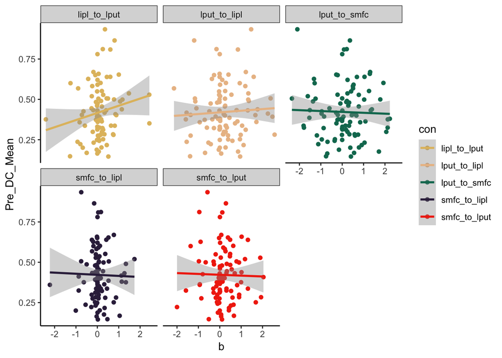

```r
draw.scatters(data, "Pre_DC_Mean")
```

```r
lapply(unique(data$con), get.cors, data = data, dv = "Pre_DC_Mean", method="spearman")
```

```
## [[1]]
##
##  Spearman's rank correlation rho
##
## data:  x and y
## S = 125660, p-value = 0.151
## alternative hypothesis: true rho is not equal to 0
## sample estimates:
##       rho
## 0.1477013
##
##
## [[2]]
##
##  Spearman's rank correlation rho
##
## data:  x and y
## S = 141610, p-value = 0.7015
## alternative hypothesis: true rho is not equal to 0
## sample estimates:
##        rho
## 0.03955507
##
##
## [[3]]
##
##  Spearman's rank correlation rho
##
## data:  x and y
## S = 143160, p-value = 0.7786
## alternative hypothesis: true rho is not equal to 0
## sample estimates:
##        rho
## 0.02901519
##
##
## [[4]]
##
##  Spearman's rank correlation rho
##
## data:  x and y
## S = 148330, p-value = 0.9537
## alternative hypothesis: true rho is not equal to 0
## sample estimates:
##          rho
## -0.006009244
##
##
## [[5]]
##
##  Spearman's rank correlation rho
##
## data:  x and y
## S = 138570, p-value = 0.5598
## alternative hypothesis: true rho is not equal to 0
## sample estimates:
##        rho
## 0.06016007
```

### Summed multitasking-cost

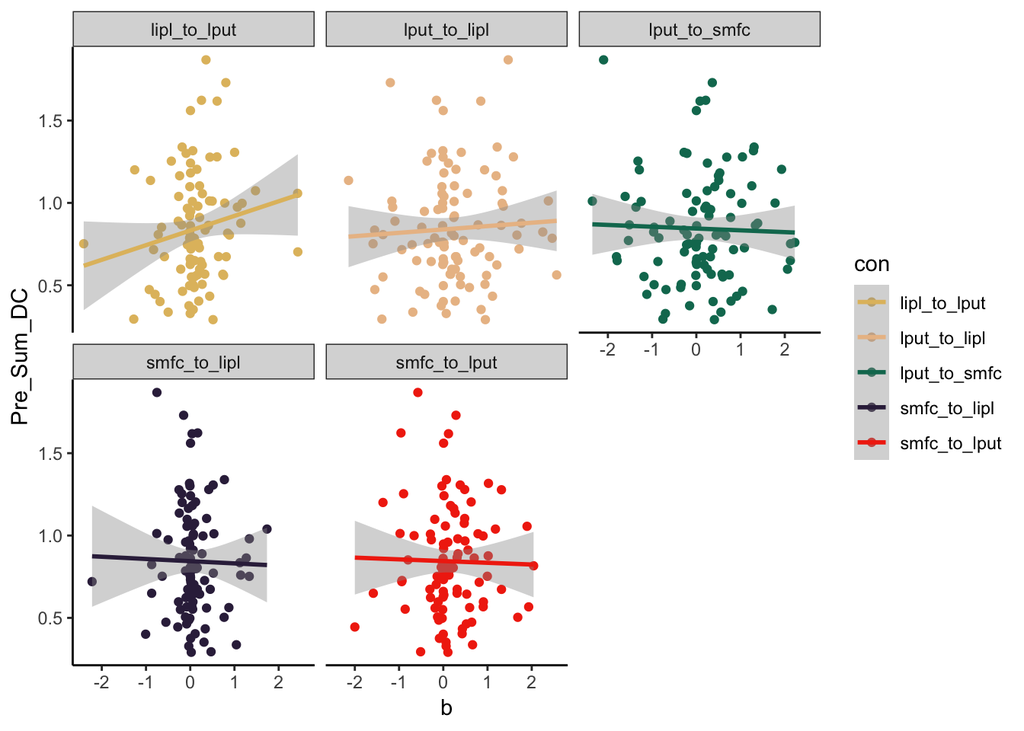

```r
draw.scatters(data, "Pre_Sum_DC")
```

```r
lapply(unique(data$con), get.cors, data = data, dv = "Pre_Sum_DC", method="spearman")
```

```
## [[1]]
##
##  Spearman's rank correlation rho
##
## data:  x and y
## S = 125660, p-value = 0.151
## alternative hypothesis: true rho is not equal to 0
## sample estimates:
##       rho
## 0.1477013
##
##
## [[2]]
##
##  Spearman's rank correlation rho
##
## data:  x and y
## S = 141610, p-value = 0.7015
## alternative hypothesis: true rho is not equal to 0
## sample estimates:
##        rho
## 0.03955507
##
##
## [[3]]
##
##  Spearman's rank correlation rho
##
## data:  x and y
## S = 143160, p-value = 0.7786
## alternative hypothesis: true rho is not equal to 0
## sample estimates:
##        rho
## 0.02901519
##
##
## [[4]]
##
##  Spearman's rank correlation rho
##
## data:  x and y
## S = 148330, p-value = 0.9537
## alternative hypothesis: true rho is not equal to 0
## sample estimates:
##          rho
## -0.006009244
##
##
## [[5]]
##
##  Spearman's rank correlation rho
##
## data:  x and y
## S = 138570, p-value = 0.5598
## alternative hypothesis: true rho is not equal to 0
## sample estimates:
##        rho
## 0.06016007
```